# Times_Series_Temp_Melbourne

## Anaïs BELLIA

```python
import numpy as np
import pandas as pd
import seaborn as sns
#pip install matplotlib
import matplotlib.pyplot as plt
from matplotlib.pyplot import figure
%matplotlib inline
import statsmodels.graphics.tsaplots as tsa
from statsmodels.tsa.exponential_smoothing.ets import ETSModel
from statsmodels.tsa.seasonal import seasonal_decompose
from statsmodels.tsa.arima.model import ARIMA as ARIMA
from patsy import dmatrices
from statsmodels.tsa.seasonal import seasonal_decompose
from dateutil.parser import parse
import itertools
import statsmodels.api as sm
```

#### Dataset : https://www.kaggle.com/datasets/paulbrabban/daily-minimum-temperatures-in-melbourne?resource=download

This data set out the minimum normal temperature in the city of Melbourne in Australia for 10 years from 1981-1990. There is a Daily temperature everyday for 10 years

```python
temp = pd.read_csv('temp.csv', parse_dates =["Date"], index_col ="Date", on_bad_lines='skip')
temp
```

| Date | Daily temp |
| --- | --- |
| 1981-01-01 | 20.7 |
| 1981-01-02 | 17.9 |
| 1981-01-03 | 18.8 |
| 1981-01-04 | 14.6 |
| 1981-01-05 | 15.8 |
| ... | ... |
| 1990-12-27 | 14.0 |
| 1990-12-28 | 13.6 |
| 1990-12-29 | 13.5 |
| 1990-12-30 | 15.7 |
| 1990-12-31 | 13.0 |

3650 rows × 1 columns

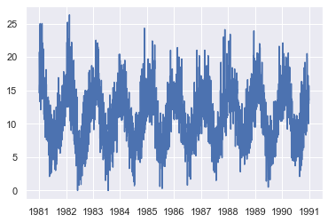

```python
temp = pd.DataFrame(temp['Daily temp'])
type(temp)
temp['Daily temp'] # c'est lui le time series et avocat_ts est un df
# convert column Daily Temp into numeric column to plot it
temp['Daily temp']=pd.to_numeric(temp['Daily temp'], errors='coerce')
plt.plot(temp)
```

## Resampling

Resampling involves changing the frequency of the time series observations.

Two types of resampling are:

Upsampling: Where we increase the frequency of the samples, such as from minutes to seconds.

Downsampling: Where we decrease the frequency of the samples, such as from days to months.

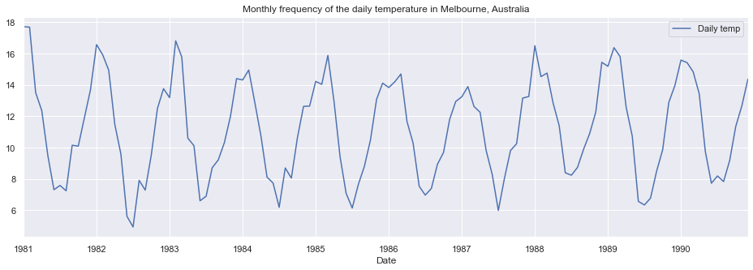

```python
# We can resample with daily frequency but the output is quite ununderstandable.
# I chosed to downsample the resampling as monthly to have a better 'human' point of view
resample_weekly = temp.resample('M')
monthly_frequency = resample_weekly.mean()
monthly_frequency.plot(figsize = (16, 5))
plt.title("Monthly frequency of the daily temperature in Melbourne, Australia")
plt.show()
#len(monthly_frequency)
```

If we set the resampling to a monthly frequency, we can see that the there is a seasonality. Obviously, the seasonality is linked to the seasons in Australia, They highest daily temperatures occur during the begining of the year in january with 16°, then drop down in June with a daily temperature of 8° wich tend to correspond to what can be found on internet

From now on, monthly_frequency is the dataset we are working with

monthly_frequency['Daily temp'] is the resampled dataframe of temp['Daily temp']

monthly_frequency and temp are both df

## Generate descriptive statistics.

```python
monthly_frequency.describe()
# si la serie Yt = Rt, alors que des variation aléatoires, pas de saisonalité, tendances
```

|  | Daily temp |
| --- | --- |
| count | 120.000000 |
| mean | 11.204819 |
| std | 3.133478 |
| min | 4.927586 |
| 25% | 8.461667 |
| 50% | 11.117742 |
| 75% | 13.772581 |
| max | 17.712903 |